# Profiling Walksheds

Antonio Paez

2024-10-21

In this document we profile the ped sheds based on their network attributes.

WARNING: Rerunning this notebook can cause the training of the evolutionary trees to deviate slightly from the reported results.

# Preliminaries

Load packages:

```r
library(broom) # Convert Statistical Objects into Tidy Tibbles
library(dplyr) # A Grammar of Data Manipulation
library(evtree) # Evolutionary Learning of Globally Optimal Trees
library(ggparty) # 'ggplot' Visualizations for the 'partykit' Package
library(ggplot2) # Create Elegant Data Visualisations Using the Grammar of Graphics
library(glue) # Interpreted String Literals
library(gt) # Easily Create Presentation-Ready Display Tables
library(patchwork) # The Composer of Plots
library(tidyr) # Tidy Messy Data
library(tree) # Classification and Regression Trees
library(sf) # Simple Features for R
library(skimr) # Compact and Flexible Summaries of Data
library(SOMbrero) # SOM Bound to Realize Euclidean and Relational Outputs
library(stringr) # Simple, Consistent Wrappers for Common String Operations
library(units) # Measurement Units for R Vectors
library(vaccHamilton) # A Data Package to Estimate Accessibility of Vaccination Sites in Hamilton, ON
```

Load data:

```r
load(file = glue::glue(here::here(), "/data/amenities_walkshed_da.rda"))
load(file = glue::glue(here::here(), "/data/hamilton_net.rda"))
load(file = glue::glue(here::here(), "/data/urban_hammer_da.rda"))
data("urban_types")
load(file = glue::glue(here::here(), "/data/walksheds_da.rda"))
load(file = glue::glue(here::here(), "/data/walksheds_da_net_vars.rda"))
load(file = glue::glue(here::here(), "/data/walksheds_validation.rda"))
load(file = glue::glue(here::here(), "/data/walksheds_validation_net_vars.rda"))
```

Bind the centroid and non-centroid walksheds (da and validations, but bound could be used in more imaginative ways for cross-validation, for example):

```r
walksheds <- bind_rows(walksheds_da,
                       walksheds_validation) |>
  mutate(origin_type = rep(c("centroid", "non-centroid"), each = nrow(walksheds_da)))
```

Obtain training and validation datasets by sampling from centroid and non-centroid walksheds:

```r
seed <- 3626425

# slice_sample() will select one of two rows for each DA at random
walksheds_train <- walksheds |>
  group_by(GeoUID) |>
  slice_sample(prop = 0.5)

# The antijoin will keep the rows in walksheds that do not appear in walksheds_train
walksheds_test <- walksheds |>
  anti_join(walksheds_train |>
              st_drop_geometry() |>
              select(GeoUID, origin_type),
            by = c("GeoUID", "origin_type"))
```

Bind the centroid and non-centroid dataframes with walkshed network variables (da and validations):

```r
walksheds_net_vars <- bind_rows(walksheds_da_net_vars,
                                walksheds_validation_net_vars) |>
  mutate(origin_type = rep(c("centroid", "non-centroid"), each = nrow(walksheds_da)))
```

Now filter from the network variables to obtain training and test datasets:

```r
walksheds_train_net_vars <- walksheds_net_vars |>
  semi_join(walksheds_train |>
              st_drop_geometry() |>
              select(GeoUID, origin_type),
            by = c("GeoUID", "origin_type"))

walksheds_test_net_vars <- walksheds_net_vars |>
  semi_join(walksheds_test |>
              st_drop_geometry() |>
              select(GeoUID, origin_type),
            by = c("GeoUID", "origin_type"))
```

Check these dataframes for NAs, inf, or other anomalies:

```r
summary(walksheds_train_net_vars)
```

```
    GeoUID                Type        n_nodes        transitivity        motifs_3         motifs_4          n_edges
 Length:834         Suburban:492   Min.   :   2.0   Min.   :0.00000   Min.   :   0.0   Min.   :    0.0   Min.   :   2.0
 Class :character   Urban   :342   1st Qu.: 188.0   1st Qu.:0.02923   1st Qu.: 389.5   1st Qu.:  786.2   1st Qu.: 460.5
 Mode  :character                  Median : 320.5   Median :0.04144   Median : 701.0   Median : 1418.0   Median : 797.0
                                   Mean   : 421.4   Mean   :0.04450   Mean   :1019.3   Mean   : 2254.0   Mean   :1091.0
                                   3rd Qu.: 485.0   3rd Qu.:0.05604   3rd Qu.:1159.2   3rd Qu.: 2550.8   3rd Qu.:1270.0
                                   Max.   :2245.0   Max.   :0.20690   Max.   :6373.0   Max.   :15649.0   Max.   :6122.0
                                                    NA's   :1
    diameter          radius           girth     global_efficiency    edge_density      edge_connectivity mean_distance
 Min.   : 840.1   Min.   : 0.000   Min.   :  3   Min.   :0.0005231   Min.   :0.001207   Min.   :0.000     Min.   : 271.7
 1st Qu.:2077.8   1st Qu.: 1.000   1st Qu.:  3   1st Qu.:0.0020026   1st Qu.:0.005272   1st Qu.:0.000     1st Qu.: 752.3
 Median :2217.5   Median : 1.000   Median :  3   Median :0.0021778   Median :0.007678   Median :0.000     Median : 818.0
 Mean   :2331.7   Mean   : 4.032   Mean   :Inf   Mean   :0.0024179   Mean   :0.014073   Mean   :0.217     Mean   : 803.1
 3rd Qu.:2497.1   3rd Qu.: 2.000   3rd Qu.:  3   3rd Qu.:0.0025055   3rd Qu.:0.012920   3rd Qu.:0.000     3rd Qu.: 870.7
 Max.   :6185.1   Max.   :28.000   Max.   :Inf   Max.   :0.0194058   Max.   :1.000000   Max.   :1.000     Max.   :1380.6

    min_cut      origin_type
 Min.   :0.000   Length:834
 1st Qu.:0.000   Class :character
 Median :0.000   Mode  :character
 Mean   :0.217
 3rd Qu.:0.000
 Max.   :1.000
```

```r
summary(walksheds_test_net_vars)
```

```
    GeoUID                Type        n_nodes        transitivity        motifs_3         motifs_4          n_edges
 Length:834         Suburban:492   Min.   :   8.0   Min.   :0.00000   Min.   :  11.0   Min.   :    9.0   Min.   :  18
 Class :character   Urban   :342   1st Qu.: 196.0   1st Qu.:0.02943   1st Qu.: 403.5   1st Qu.:  799.2   1st Qu.: 470
 Mode  :character                  Median : 321.0   Median :0.04076   Median : 692.0   Median : 1408.5   Median : 804
                                   Mean   : 425.9   Mean   :0.04426   Mean   :1031.8   Mean   : 2283.5   Mean   :1103
                                   3rd Qu.: 499.8   3rd Qu.:0.05646   3rd Qu.:1209.2   3rd Qu.: 2689.2   3rd Qu.:1295
                                   Max.   :2373.0   Max.   :0.13953   Max.   :6865.0   Max.   :16841.0   Max.   :6590
    diameter          radius           girth     global_efficiency    edge_density      edge_connectivity mean_distance
 Min.   : 672.1   Min.   : 0.000   Min.   :  3   Min.   :0.0009897   Min.   :0.001171   Min.   :0.0000    Min.   : 373.1
 1st Qu.:2090.2   1st Qu.: 1.000   1st Qu.:  3   1st Qu.:0.0020012   1st Qu.:0.005112   1st Qu.:0.0000    1st Qu.: 759.8
 Median :2223.6   Median : 1.000   Median :  3   Median :0.0021793   Median :0.007728   Median :0.0000    Median : 826.5
 Mean   :2367.6   Mean   : 4.163   Mean   :Inf   Mean   :0.0023586   Mean   :0.012022   Mean   :0.2266    Mean   : 812.5
 3rd Qu.:2485.7   3rd Qu.: 2.000   3rd Qu.:  3   3rd Qu.:0.0024916   3rd Qu.:0.012349   3rd Qu.:0.0000    3rd Qu.: 877.3
 Max.   :6185.1   Max.   :29.000   Max.   :Inf   Max.   :0.0068181   Max.   :0.321429   Max.   :1.0000    Max.   :1420.4
    min_cut       origin_type
 Min.   :0.0000   Length:834
 1st Qu.:0.0000   Class :character
 Median :0.0000   Mode  :character
 Mean   :0.2266
 3rd Qu.:0.0000
 Max.   :1.0000
```

## Classification tree

The aim is to train a classification tree to profile urban and suburban walksheds based on the attributes of the network. We need to drop 1 observation that has an NA in `transitivity`:

```r
d <- walksheds_train_net_vars |>
  select(-girth) |>
  drop_na() |>
  mutate(normalized_motifs_3 = motifs_3/n_edges,
         normalized_motifs_4 = motifs_4/n_edges)

d_test <- walksheds_test_net_vars |>
  select(-girth) |>
  drop_na() |>
  mutate(normalized_motifs_3 = motifs_3/n_edges,
         normalized_motifs_4 = motifs_4/n_edges)
```

We use a technique with evolutionary trees - an alternative to classification trees that is less affected by the greediness of the algorithm. Since evolutionary trees have some randomness (for the initial values), we can try several to find whether there are patterns.

Bunch of trees with random seeds. First, make sure that the seeds are reproducible:

```r
n_trees <- 30 # select number of trees
set.seed(98732475)
seeds <- sample.int(1000000, n_trees)
```

Traaaain!

```r
counter <- 0
trees <- list()
for(i in seeds){
  counter <- counter + 1
  #set.seed(seeds[counter])
  #tree_name <- glue::glue("tree{counter}")
  trees[[counter]] <- evtree(Type ~ .,
                             data = d |>
                               select(-c(GeoUID, motifs_3, motifs_4, n_edges, n_nodes, origin_type)),
                             control = evtree.control(seed = seeds[counter]))
}
```

Name the trees in the list above:

```r
named_trees <- data.frame(t = "evtree ", count = c(1:n_trees)) |>
  mutate(t = glue::glue("{t}{count}"))

names(trees) <- named_trees$t
```

Check the attributes of the trees:

```r
trees
```

```
$`evtree 1`

Model formula:
Type ~ transitivity + diameter + radius + global_efficiency +
    edge_density + edge_connectivity + mean_distance + min_cut +
    normalized_motifs_3 + normalized_motifs_4

Fitted party:
[1] root
|   [2] edge_density < 0.02539
|   |   [3] normalized_motifs_3 < 0.96853
|   |   |   [4] normalized_motifs_3 < 0.86585
|   |   |   |   [5] diameter < 1632.889: Urban (n = 10, err = 10.0%)
|   |   |   |   [6] diameter >= 1632.889: Suburban (n = 312, err = 18.3%)
|   |   |   [7] normalized_motifs_3 >= 0.86585
|   |   |   |   [8] edge_density < 0.00591: Urban (n = 109, err = 17.4%)
|   |   |   |   [9] edge_density >= 0.00591: Suburban (n = 190, err = 19.5%)
|   |   [10] normalized_motifs_3 >= 0.96853: Urban (n = 139, err = 0.7%)
|   [11] edge_density >= 0.02539: Suburban (n = 73, err = 15.1%)

Number of inner nodes:    5
Number of terminal nodes: 6

$`evtree 2`

Model formula:
Type ~ transitivity + diameter + radius + global_efficiency +
    edge_density + edge_connectivity + mean_distance + min_cut +
    normalized_motifs_3 + normalized_motifs_4

Fitted party:
[1] root
|   [2] edge_density < 0.02376
|   |   [3] normalized_motifs_3 < 0.86585
|   |   |   [4] mean_distance < 602.97417: Urban (n = 16, err = 31.2%)
|   |   |   [5] mean_distance >= 602.97417
|   |   |   |   [6] transitivity < 0.02262: Urban (n = 17, err = 35.3%)
|   |   |   |   [7] transitivity >= 0.02262: Suburban (n = 280, err = 15.0%)
|   |   [8] normalized_motifs_3 >= 0.86585
|   |   |   [9] edge_density < 0.00591: Urban (n = 213, err = 9.4%)
```

[output cut: 556 more lines]

```
Fitted party:
[1] root
|   [2] edge_density < 0.02553
|   |   [3] normalized_motifs_3 < 0.86585
|   |   |   [4] diameter < 1648.233: Urban (n = 10, err = 10.0%)
|   |   |   [5] diameter >= 1648.233: Suburban (n = 314, err = 18.2%)
|   |   [6] normalized_motifs_3 >= 0.86585
|   |   |   [7] edge_density < 0.00591: Urban (n = 213, err = 9.4%)
|   |   |   [8] edge_density >= 0.00591
|   |   |   |   [9] normalized_motifs_3 < 0.96699: Suburban (n = 190, err = 19.5%)
|   |   |   |   [10] normalized_motifs_3 >= 0.96699: Urban (n = 35, err = 0.0%)
|   [11] edge_density >= 0.02553: Suburban (n = 71, err = 15.5%)

Number of inner nodes:    5
Number of terminal nodes: 6
```

The frequency of variables in this set of tree is as follows:

| Variable | Number of trees where it appears |
| --- | --- |
| edge_density | IIIII IIIII IIIII IIIII IIIII IIIII |
| normalized_motifs_3 | IIIII IIIII IIIII IIIII IIIII IIIII |
| diameter | IIIII II |
| transitivity | II |
| mean_distance | II |
| normalized_motifs_4 | I |

The pattern is dominated by edge_density and normalized_motifs_3, and this has been the case after repeating this procedure several times. By now I must have trained over 150 trees.

There is something about reproducing the trained trees; after restarting the computer, using the same seed does not replicate the trees; after doing this process several times, the results are very similar, but to avoid problems with slightly different trees being produced every time, save the results of this run):

```r
# WARNING: Run only if you wish to replace the file with the results used in the report
# Save to `data` folder
save(trees,
     file = glue::glue(here::here(), "/data/trees.rda"),
     compress = "xz")
```

Examine missclassification in training dataset. The missclassification is the proportion of times that the predicted class is different from the observed class. The evaluation function uses the missclassification rate but penalizes by complexity (number of nodes in the tree):

```r
mc <- function(obj) 1 - mean(predict(obj) == d$Type)


evalfun <- function(obj) 2 * nrow(d) * mc(obj) + width(obj) * log(nrow(d))

#trees <- list("evtree" = tree1, "rpart" = rp, "ctree" = ct, "rpart2" = rp2, "ctree2" = ct2)
#trees <- list("evtree 1" = tree1, "evtree 2" = tree2, "evtree 3" = tree3, "evtree 4" = tree4)

mc_train <- round(sapply(trees, function(obj) c("misclassification" = mc(obj), "evaluation function" = evalfun(obj))), digits = 7)
mc_train
```

```
                       evtree 1    evtree 2    evtree 3    evtree 4    evtree 5    evtree 6    evtree 7    evtree 8    evtree 9
misclassification     0.1512605   0.1476591   0.1644658   0.1644658   0.1512605   0.1644658   0.1560624   0.1644658   0.1644658
evaluation function 292.3502019 293.0752355 300.9001346 300.9001346 292.3502019 300.9001346 300.3502019 300.9001346 300.9001346
                      evtree 10   evtree 11   evtree 12   evtree 13   evtree 14   evtree 15   evtree 16   evtree 17   evtree 18
misclassification     0.1512605   0.1644658   0.1644658   0.1644658   0.1512605   0.1644658   0.1644658   0.1644658   0.1644658
evaluation function 292.3502019 300.9001346 300.9001346 300.9001346 292.3502019 300.9001346 300.9001346 300.9001346 300.9001346
                      evtree 19   evtree 20   evtree 21   evtree 22   evtree 23   evtree 24   evtree 25   evtree 26   evtree 27
misclassification     0.1644658   0.1644658   0.1644658   0.1644658   0.1512605   0.1644658   0.1644658   0.1512605   0.1644658
evaluation function 300.9001346 300.9001346 300.9001346 300.9001346 292.3502019 300.9001346 300.9001346 292.3502019 300.9001346
                      evtree 28   evtree 29   evtree 30
misclassification     0.1548619   0.1644658   0.1512605
evaluation function 298.3502019 300.9001346 292.3502019
```

Examine missclassificationon the test data:

```r
mc <- function(obj) 1 - mean(predict(obj, newdata = d_test) == d_test$Type)


evalfun <- function(obj) 2 * nrow(d_test) * mc(obj) + width(obj) * log(nrow(d_test))

#trees <- list("evtree" = tree1, "rpart" = rp, "ctree" = ct, "rpart2" = rp2, "ctree2" = ct2)
#trees <- list("evtree 1" = tree1, "evtree 2" = tree2, "evtree 3" = tree3, "evtree 4" = tree4)

mc_test <- round(sapply(trees, function(obj) c("misclassification" = mc(obj), "evaluation function" = evalfun(obj))), digits = 7)
mc_test
```

```
                       evtree 1    evtree 2    evtree 3    evtree 4    evtree 5    evtree 6    evtree 7    evtree 8    evtree 9
misclassification     0.1738609   0.1786571   0.1738609   0.1702638   0.1702638   0.1702638   0.1666667   0.1702638   0.1738609
evaluation function 330.3574004 345.0836338 316.9049336 310.9049336 324.3574004 310.9049336 318.3574004 310.9049336 316.9049336
                      evtree 10   evtree 11   evtree 12   evtree 13   evtree 14   evtree 15   evtree 16   evtree 17   evtree 18
misclassification     0.1714628   0.1702638   0.1738609   0.1738609   0.1714628   0.1738609   0.1738609   0.1738609   0.1702638
evaluation function 326.3574004 310.9049336 316.9049336 316.9049336 326.3574004 316.9049336 316.9049336 316.9049336 310.9049336
                      evtree 19   evtree 20   evtree 21   evtree 22   evtree 23   evtree 24   evtree 25   evtree 26   evtree 27
misclassification     0.1702638   0.1738609   0.1702638   0.1738609   0.1738609   0.1702638   0.1702638   0.1702638   0.1738609
evaluation function 310.9049336 316.9049336 310.9049336 316.9049336 330.3574004 310.9049336 310.9049336 324.3574004 316.9049336
                     evtree 28   evtree 29   evtree 30
misclassification     0.176259   0.1738609   0.1738609
evaluation function 334.357400 316.9049336 330.3574004
```

```r
(mc_train[2,] + mc_test[2,])/2
```

```
 evtree 1  evtree 2  evtree 3  evtree 4  evtree 5  evtree 6  evtree 7  evtree 8  evtree 9 evtree 10 evtree 11 evtree 12 evtree 13
 311.3538  319.0794  308.9025  305.9025  308.3538  305.9025  309.3538  305.9025  308.9025  309.3538  305.9025  308.9025  308.9025
evtree 14 evtree 15 evtree 16 evtree 17 evtree 18 evtree 19 evtree 20 evtree 21 evtree 22 evtree 23 evtree 24 evtree 25 evtree 26
 309.3538  308.9025  308.9025  308.9025  305.9025  305.9025  308.9025  305.9025  308.9025  311.3538  305.9025  305.9025  308.3538
evtree 27 evtree 28 evtree 29 evtree 30
 308.9025  316.3538  308.9025  311.3538
```

There are several ties, but are actually variations of the same model. Choose Tree 4:

```r
best_evtree <- trees[[4]]
```

Plot the tree:

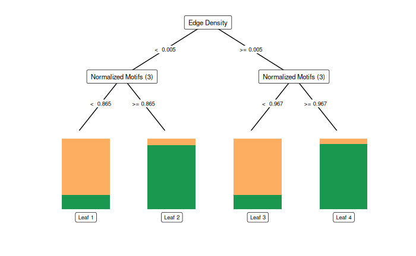

The leaves are as follows:

| Leaf | Character |
| --- | --- |
| Leaf 1 | Suburban |
| Leaf 2 | Urban |
| Leaf 3 | Suburban |
| Leaf 4 | Urban |

Check the break labels of `tree4` to round:

```r
ggparty(best_evtree)$data$breaks_label
```

```
[[1]]
[1] NA

[[2]]
[1] "NA <  NA* 0.00590599876314162"

[[3]]
[1] "NA <  NA* 0.865853658536585"

[[4]]
[1] "NA >= NA* 0.865853658536585"

[[5]]
[1] "NA >= NA* 0.00590599876314162"

[[6]]
[1] "NA <  NA* 0.967078189300412"

[[7]]
[1] "NA >= NA* 0.967078189300412"
```

Use the classification tree to add classes to train data:

```r
d <- d |>
  mutate(leaf = case_when(edge_density < 0.00590599876314162 & normalized_motifs_3 < 0.865853658536585  ~ "Leaf 1",
                          edge_density < 0.00590599876314162 & normalized_motifs_3 >= 0.865853658536585 ~ "Leaf 2",
                          edge_density >= 0.00590599876314162 & normalized_motifs_3 < 0.967078189300412 ~ "Leaf 3",
                          edge_density >= 0.00590599876314162 & normalized_motifs_3 >= 0.967078189300412 ~ "Leaf 4") ,
         leaf = factor(leaf))
```

Use the classification tree to add classes to test data:

```r
d_test <- d_test |>
  mutate(leaf = case_when(edge_density < 0.00590599876314162 & normalized_motifs_3 < 0.865853658536585  ~ "Leaf 1",
                          edge_density < 0.00590599876314162 & normalized_motifs_3 >= 0.865853658536585 ~ "Leaf 2",
                          edge_density >= 0.00590599876314162 & normalized_motifs_3 < 0.967078189300412 ~ "Leaf 3",
                          edge_density >= 0.00590599876314162 & normalized_motifs_3 >= 0.967078189300412 ~ "Leaf 4") ,
         leaf = factor(leaf))
```

Join the classes to walksheds:

```r
walksheds_train <- walksheds_train |>
  left_join(d |>
              st_drop_geometry() |>
              select(GeoUID,
                     Type,
                     leaf),
            by = c("GeoUID",
                   "Type"))
```

Examples of networks and walksheds by leaf.

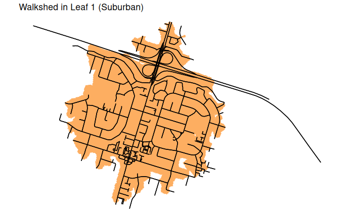

Leaf 2 (Urban):

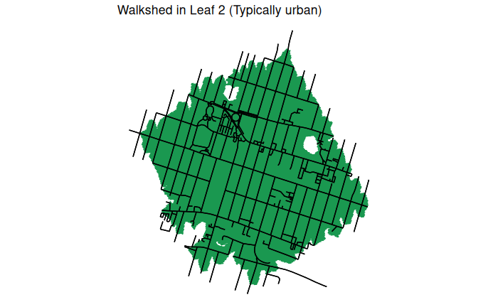

```r
set.seed(29919)

walkshed_leaf_2 <- walksheds_train |>
  ungroup () |>
  filter(leaf == "Leaf 2") |>
  slice_sample(n = 1)

leaf_2_plot <- hamilton_net$edges |>
  st_intersection(walkshed_leaf_2)
leaf_2_plot <- hamilton_net$edges |>
  filter(edge_index %in% leaf_2_plot$edge_index) |>
  st_transform(crs = st_crs(urban_types))

walkshed_leaf_2 <- walkshed_leaf_2 |>
  st_transform(crs = st_crs(urban_types))

# Find the center of the bounding box; we'll use it to plot on a false origin and fixed extent
max_x_2 <- st_bbox(leaf_2_plot)[3] - st_bbox(leaf_2_plot)[1]
max_y_2 <- st_bbox(leaf_2_plot)[4] - st_bbox(leaf_2_plot)[2]
center_2 <- c(max_x_2/2 + st_bbox(leaf_2_plot)[1], max_y_2/2 + st_bbox(leaf_2_plot)[2])

ggplot() +
  geom_sf(data = walkshed_leaf_2,
          color = "#1A9850",
          fill = "#1A9850") +
  geom_sf(data = leaf_2_plot) +
  ggtitle("Walkshed in Leaf 2 (Typically urban)") +
  theme_void()
```

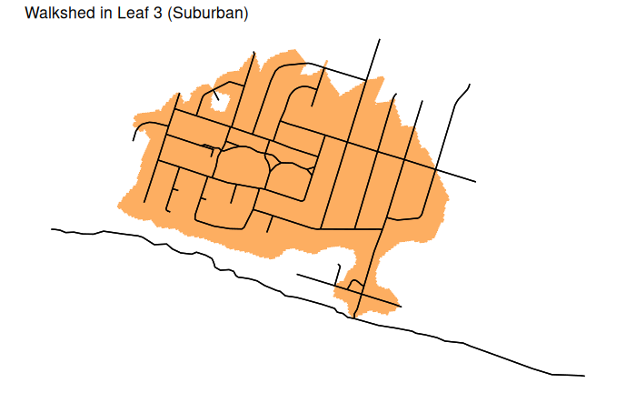

```r
set.seed(29922)

walkshed_leaf_3 <- walksheds_train |>
  ungroup () |>
  filter(leaf == "Leaf 3") |>
  slice_sample(n = 1)

leaf_3_plot <- hamilton_net$edges |>
  st_intersection(walkshed_leaf_3)
leaf_3_plot <- hamilton_net$edges |>
  filter(edge_index %in% leaf_3_plot$edge_index) |>
  st_transform(crs = st_crs(urban_types))

walkshed_leaf_3 <- walkshed_leaf_3 |>
  st_transform(crs = st_crs(urban_types))

# Find the center of the bounding box; we'll use it to plot on a false origin and fixed extent
max_x_3 <- st_bbox(leaf_3_plot)[3] - st_bbox(leaf_3_plot)[1]
max_y_3 <- st_bbox(leaf_3_plot)[4] - st_bbox(leaf_3_plot)[2]
center_3 <- c(max_x_3/2 + st_bbox(leaf_3_plot)[1], max_y_3/2 + st_bbox(leaf_3_plot)[2])

ggplot() +
  geom_sf(data = walkshed_leaf_3,
          color = "#FDAE61",
          fill = "#FDAE61") +
  geom_sf(data = leaf_3_plot) +
  ggtitle("Walkshed in Leaf 3 (Suburban)") +
  theme_void()
```

Leaf 4 (Urban):

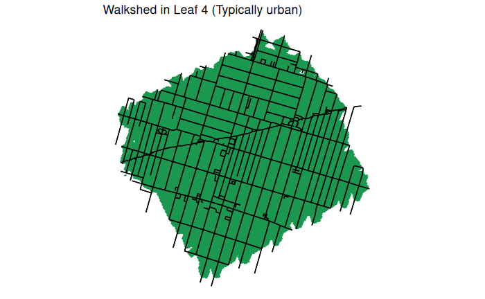

```r
set.seed(29946765)

walkshed_leaf_4 <- walksheds_train |>
  ungroup () |>
  filter(leaf == "Leaf 4") |>
  slice_sample(n = 1)

leaf_4_plot <- hamilton_net$edges |>
  st_intersection(walkshed_leaf_4)
leaf_4_plot <- hamilton_net$edges |>
  filter(edge_index %in% leaf_4_plot$edge_index) |>
  st_transform(crs = st_crs(urban_types))

walkshed_leaf_4 <- walkshed_leaf_4 |>
  st_transform(crs = st_crs(urban_types))

# Find the center of the bounding box; we'll use it to plot on a false origin and fixed extent
max_x_4 <- st_bbox(leaf_4_plot)[3] - st_bbox(leaf_4_plot)[1]
max_y_4 <- st_bbox(leaf_4_plot)[4] - st_bbox(leaf_4_plot)[2]
center_4 <- c(max_x_4/2 + st_bbox(leaf_4_plot)[1], max_y_4/2 + st_bbox(leaf_4_plot)[2])

ggplot() +
  geom_sf(data = walkshed_leaf_4,
          color = "#1A9850",
          fill = "#1A9850") +
  geom_sf(data =leaf_4_plot) +
  ggtitle("Walkshed in Leaf 4 (Typically urban)") +
  theme_void()
```

Find the max extent in x and y:

```r
max_x <- max(c(max_x_1, max_x_2, max_x_3, max_x_4))
max_y <- max(c(max_y_1, max_y_2, max_y_3, max_y_4))
```

Function to translate the objects to center them at a false origin of zero:

```r
leaf_1_gg <- ggplot() +
  geom_sf(data = walkshed_leaf_1,
          color = "#FDAE61",
          fill = "#FDAE61") +
  geom_sf(data = leaf_1_plot) +
  theme_void()

leaf_2_gg <- ggplot() +
  geom_sf(data = walkshed_leaf_2,
          color = "#1A9850",
          fill = "#1A9850") +
  geom_sf(data = leaf_2_plot) +
  theme_void()

leaf_3_gg <- ggplot() +
  geom_sf(data = walkshed_leaf_3,
          color = "#FDAE61",
          fill = "#FDAE61") +
  geom_sf(data = leaf_3_plot) +
  theme_void()

leaf_4_gg <- ggplot() +
  geom_sf(data = walkshed_leaf_4,
          color = "#1A9850",
          fill = "#1A9850") +
  geom_sf(data =leaf_4_plot) +
  theme_void()
```

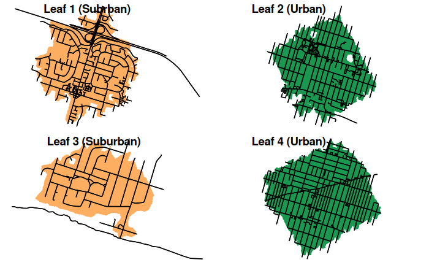

```r
sample_sheds_by_urban_type <- cowplot::plot_grid(leaf_1_gg, leaf_2_gg, leaf_3_gg, leaf_4_gg,
                   nrow = 2,
                   ncol = 2,
                   labels = c("Leaf 1 (Subrban)", "Leaf 2 (Urban)", "Leaf 3 (Suburban)", "Leaf 4 (Urban)"))

cowplot::save_plot(sample_sheds_by_urban_type,
                   filename = glue::glue(here::here(),"/plots/sample_sheds_by_urban_type.png"),
                   nrow = 2,
                   ncol = 3,
                   base_width = 3.5)

sample_sheds_by_urban_type
```